# Self Rated Health

# 1 Description of DataSchema variable

The description of harmonised variable is the following:

- Short name: `srh`
- Variable label: `Respondent's self-rated/self-reported health`
- Variable description: `Respondent's self-rated/self-reported health on a Likert-type scale`
- Domain: `Health status and functional limitations`
- Value type: `categorical`
- Category coding:

| **Code** | **Category Label** |
| --- | --- |
| 1 | Good |
| 2 | Average/Fair/Moderate |
| 3 | Poor |

- Category missings:

| **Code** | **Category Label** |
| --- | --- |
| 991 | CAPI/interviewer error |
| 992 | Impute |
| 993 | Disable to measure |
| 994 | Not attempt/not done |
| 995 | Does not answer |
| 996 | Not applicable |
| 997 | Refuse |
| 998 | Do not know |
| 999 | Missing |

# 2 Data process

## 2.1 ELSA

### 2.1.1 Wave 1

#### 2.1.1.1 Study-specific variable description

| **Name** | `hegenh` | `hehelf` |
| --- | --- | --- |
| **Label** | `How is your health in general? Would you say it was …? {start of section}` | `Would you say your health is ... ? {start of section}` |
| **Table name** | `wave_1_core_data_v3` | `wave_1_core_data_v3` |
| **Categories** | `1 = Very good` `2 = Good` `3 = Fair` `4 = Bad` `5 = Very Bad` | `1 = Excellent` `2 = Very good` `3 = Good` `4 = Fair` `5 = Poor` |
| **Missings** | `-9 = Refusal` `-8 = Don't know` `-1 = Not applicable` | `-9 = Refusal` `-8 = Don't know` `-1 = Not applicable` |
| **Description** |  |  |

hegenh

| Sample size | Missing values |
| --- | --- |
| 12099 | 6090 |

Category

|  | 1 | 2 | 3 | 4 | 5 |
| --- | --- | --- | --- | --- | --- |
| Frequency | 1570.00 | 2445.00 | 1502.00 | 377.00 | 115.00 |
| Percentage | 12.98 | 20.21 | 12.41 | 3.12 | 0.95 |

Type of missing

|  | -9 | -8 | -1 | NA |
| --- | --- | --- | --- | --- |
| Frequency | 2.00 | 7.00 | 6081.00 | 0 |
| Percentage | 0.02 | 0.06 | 50.26 | 0 |

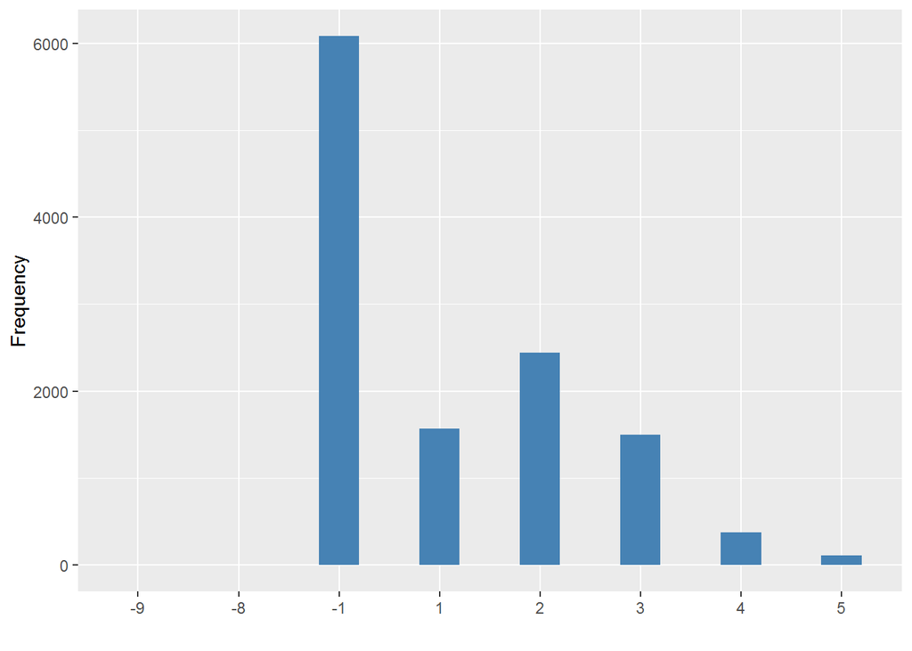

hehelf

| Sample size | Missing values |
| --- | --- |
| 12099 | 6200 |

Category

|  | 1 | 2 | 3 | 4 | 5 |
| --- | --- | --- | --- | --- | --- |
| Frequency | 819.00 | 1598.00 | 1771.00 | 1170.00 | 541.00 |
| Percentage | 6.77 | 13.21 | 14.64 | 9.67 | 4.47 |

Type of missing

|  | -9 | -8 | -1 | NA |
| --- | --- | --- | --- | --- |
| Frequency | 3.00 | 4.00 | 6193.00 | 0 |
| Percentage | 0.02 | 0.03 | 51.19 | 0 |

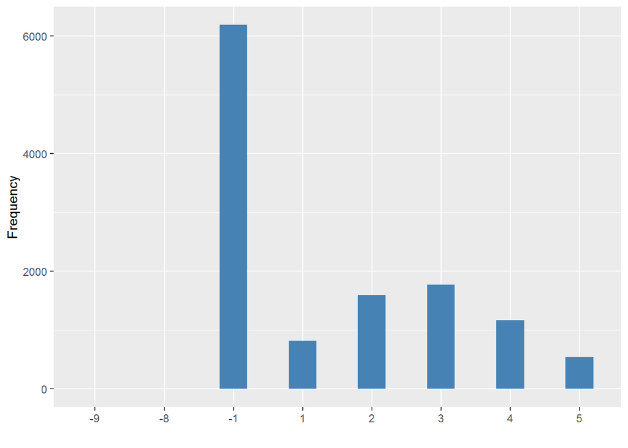

#### 2.1.1.2 Harmonisation algorithm

To compute the harmonised variable from the study-specific variables it has to be recoded as follows:

- `Excellent, Very good, Good into 1 Good`
- `4 Fair into 2 Fair/moderate`
- `5 Poor, Bad, Very bad into 3 Poor`
- `-9 Refusal into 997`
- `-8 Don't know into 998`
- `-1 Not applicable into 996`

**R script:**

```r
ELSA_ds_w1 <- tibble(id = ELSA_w1_srh$id)
ELSA_ds_w1$srh <- car::recode(ELSA_w1_srh$hehelf, "1 = '1';2 = '1';3 = '1';4 = '2';5 = '3';-9 = '997';-8 = '998';-1 = '996' ")
ELSA_ds_w1$srh[which(is.na(ELSA_w1_srh$hehelf) | ELSA_w1_srh$hehelf == -1)] <- car::recode(ELSA_w1_srh$hegenh[which(is.na(ELSA_w1_srh$hehelf) |
    ELSA_w1_srh$hehelf == -1)], "1 = '1';2 = '1';3 = '2';4 = '3';5 = '3';-9 = '997';-8 = '998';-1 = '996' ")
```

#### 2.1.1.3 Statistical description of the new harmonised variable

Self Rated Health

| Sample size | Missing values |
| --- | --- |
| 12099 | 191 |

Category

|  | 1 | 2 | 3 |
| --- | --- | --- | --- |
| Frequency | 8203.0 | 2672.00 | 1033.00 |
| Percentage | 67.8 | 22.08 | 8.54 |

Type of missing

|  | 991 | 992 | 993 | 994 | 995 | 996 | 997 | 998 | 999 | NA |
| --- | --- | --- | --- | --- | --- | --- | --- | --- | --- | --- |
| Frequency | 0 | 0 | 0 | 0 | 0 | 175.00 | 5.00 | 11.00 | 0 | 0 |
| Percentage | 0 | 0 | 0 | 0 | 0 | 1.45 | 0.04 | 0.09 | 0 | 0 |

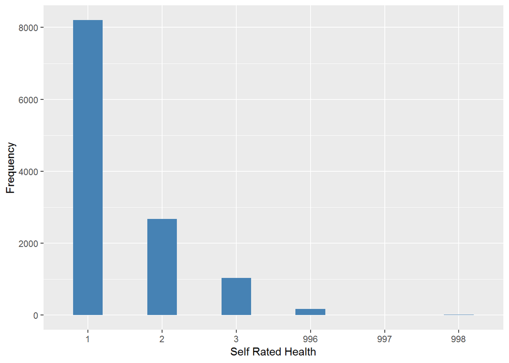

#### 2.1.1.4 Validation

### 2.1.2 Wave 2

#### 2.1.2.1 Study-specific variable description

| **Name** | `Hehelf` |
| --- | --- |
| **Label** | `Self-reported general health` |
| **Table name** | `wave_2_core_data_v4` |
| **Categories** | `1 = Excellent` `2 = Very good` `3 = Good` `4 = Fair` `5 = Poor` |
| **Missings** | `-9 = Refusal` `-8 = Don't know` `-1 = Not applicable` |
| **Description** |  |

Hehelf

| Sample size | Missing values |
| --- | --- |
| 9432 | 138 |

Category

|  | 1 | 2 | 3 | 4 | 5 |
| --- | --- | --- | --- | --- | --- |
| Frequency | 1179.0 | 2598.00 | 2934.00 | 1877.0 | 706.00 |
| Percentage | 12.5 | 27.54 | 31.11 | 19.9 | 7.49 |

Type of missing

|  | -9 | -8 | -1 | NA |
| --- | --- | --- | --- | --- |
| Frequency | 1.00 | 5.00 | 132.0 | 0 |
| Percentage | 0.01 | 0.05 | 1.4 | 0 |

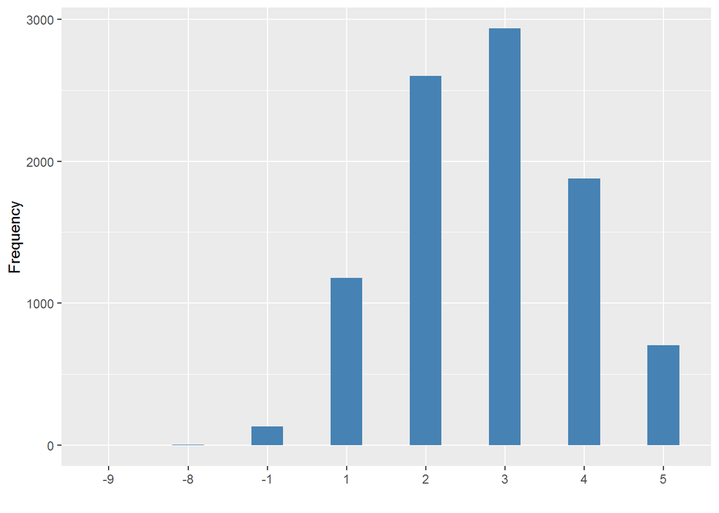

#### 2.1.2.2 Harmonisation algorithm

To compute the harmonize variable from the study-specific variable it has to be recoded as follows:

- `1 into 1`
- `2 into 1`
- `3 into 1`
- `4 into 2`
- `5 into 3`
- `-9 Refusal into 997`
- `-8 Don't know into 998`
- `-1 Not applicable into 996`

**R script:**

```r
ELSA_ds_w2 <- tibble(id = ELSA_w2_srh$id)
ELSA_ds_w2$srh <- car::recode(ELSA_w2_srh$Hehelf, "1 = '1';2 = '1';3 = '1';4 = '2';5 = '3';-9 = '997';-8 = '998';-1 = '996' ")
```

#### 2.1.2.3 Statistical description of the new harmonised variable

Self Rated Health

| Sample size | Missing values |
| --- | --- |
| 9432 | 138 |

Category

|  | 1 | 2 | 3 |
| --- | --- | --- | --- |
| Frequency | 6711.00 | 1877.0 | 706.00 |
| Percentage | 71.15 | 19.9 | 7.49 |

Type of missing

|  | 991 | 992 | 993 | 994 | 995 | 996 | 997 | 998 | 999 | NA |
| --- | --- | --- | --- | --- | --- | --- | --- | --- | --- | --- |
| Frequency | 0 | 0 | 0 | 0 | 0 | 132.0 | 1.00 | 5.00 | 0 | 0 |
| Percentage | 0 | 0 | 0 | 0 | 0 | 1.4 | 0.01 | 0.05 | 0 | 0 |

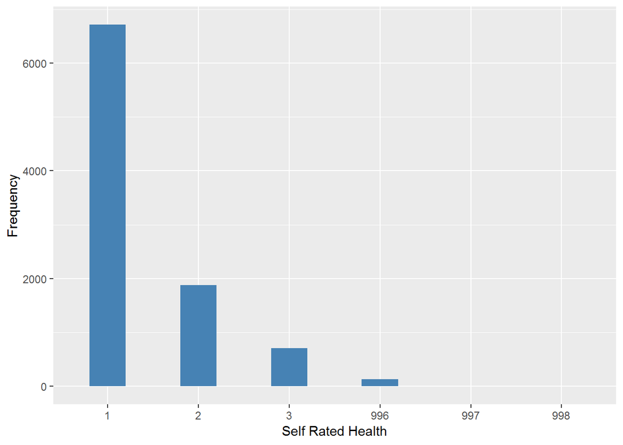

#### 2.1.2.4 Validation

|  | 1,2,3->1 | 4->2 | 5->3 | -1->996 | -9->997 | -8->998 |
| --- | --- | --- | --- | --- | --- | --- |
| BeforeH | 6711 | 1877 | 706 | 132 | 1 | 5 |
| AfterH | 6711 | 1877 | 706 | 132 | 1 | 5 |

### 2.1.3 Wave 3

#### 2.1.3.1 Study-specific variable description

| **Name** | `hegenh` |
| --- | --- |
| **Label** | `Self-reported general health` |
| **Table name** | `wave_3_elsa_data_v4` |
| **Categories** | `1 = Very good` `2 = Good` `3 = Fair` `4 = Bad` `5 = Very Bad` |
| **Missings** | `-8 = Don't know` `-1 = Not applicable` |
| **Description** |  |

hegenh

| Sample size | Missing values |
| --- | --- |
| 9771 | 237 |

Category

|  | 1 | 2 | 3 | 4 | 5 |
| --- | --- | --- | --- | --- | --- |
| Frequency | 2465.00 | 4072.00 | 2331.00 | 529.00 | 137.0 |
| Percentage | 25.23 | 41.67 | 23.86 | 5.41 | 1.4 |

Type of missing

|  | -8 | -1 | NA |
| --- | --- | --- | --- |
| Frequency | 5.00 | 232.00 | 0 |
| Percentage | 0.05 | 2.37 | 0 |

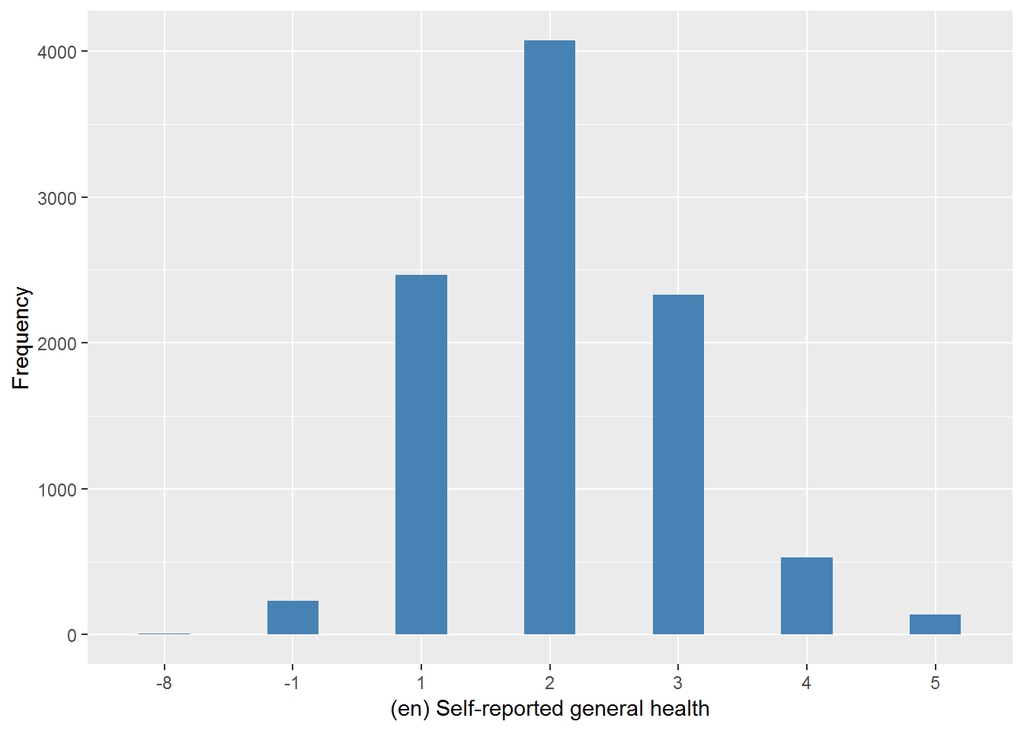

#### 2.1.3.2 Harmonisation algorithm

To compute the harmonize variable from the study-specific variable it has to be recoded as follows:

- `1 into 1`
- `2 into 1`
- `3 into 2`
- `4 into 3`
- `5 into 3`
- `-8 Don't know into 998`
- `-1 Not applicable into 996`

**R script:**

```r
ELSA_ds_w3 <- tibble(id = ELSA_w3_srh$id)
ELSA_ds_w3$srh <- car::recode(ELSA_w3_srh$hegenh, "1 = '1';2 = '1';3 = '2';4 = '3';5 = '3';-9 = '997';-8 = '998';-1 = '996' ")
```

#### 2.1.3.3 Statistical description of the new harmonised variable

Self Rated Health

| Sample size | Missing values |
| --- | --- |
| 9771 | 237 |

Category

|  | 1 | 2 | 3 |
| --- | --- | --- | --- |
| Frequency | 6537.0 | 2331.00 | 666.00 |
| Percentage | 66.9 | 23.86 | 6.82 |

Type of missing

|  | 991 | 992 | 993 | 994 | 995 | 996 | 997 | 998 | 999 | NA |
| --- | --- | --- | --- | --- | --- | --- | --- | --- | --- | --- |
| Frequency | 0 | 0 | 0 | 0 | 0 | 232.00 | 0 | 5.00 | 0 | 0 |
| Percentage | 0 | 0 | 0 | 0 | 0 | 2.37 | 0 | 0.05 | 0 | 0 |

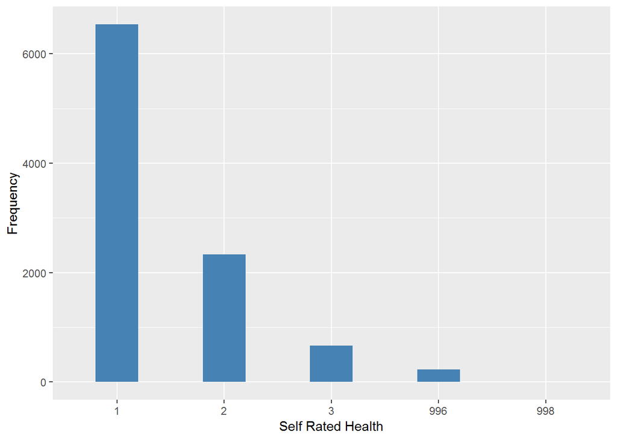

#### 2.1.3.4 Validation

|  | 1,2->1 | 3->2 | 4,5->3 | -1->996 | -8->998 |
| --- | --- | --- | --- | --- | --- |
| BeforeH | 6537 | 2331 | 666 | 232 | 5 |
| AfterH | 6537 | 2331 | 666 | 232 | 5 |

### 2.1.4 Wave 4

#### 2.1.4.1 Study-specific variable description

| **Name** | `hehelf` |
| --- | --- |
| **Label** | `Self-reported general health` |
| **Table name** | `wave_4_elsa_data_v3` |
| **Categories** | `1 = Excellent` `2 = Very good` `3 = Good` `4 = Fair` `5 = Poor` |
| **Missings** | `-9 = Refusal` `-8 = Don't know` `-1 = Not applicable` |
| **Description** |  |

hehelf

| Sample size | Missing values |
| --- | --- |
| 11050 | 456 |

Category

|  | 1 | 2 | 3 | 4 | 5 |
| --- | --- | --- | --- | --- | --- |
| Frequency | 1353.00 | 3091.00 | 3375.00 | 1994.00 | 781.00 |
| Percentage | 12.24 | 27.97 | 30.54 | 18.05 | 7.07 |

Type of missing

|  | -9 | -8 | -1 | NA |
| --- | --- | --- | --- | --- |
| Frequency | 6.00 | 4.00 | 446.00 | 0 |
| Percentage | 0.05 | 0.04 | 4.04 | 0 |

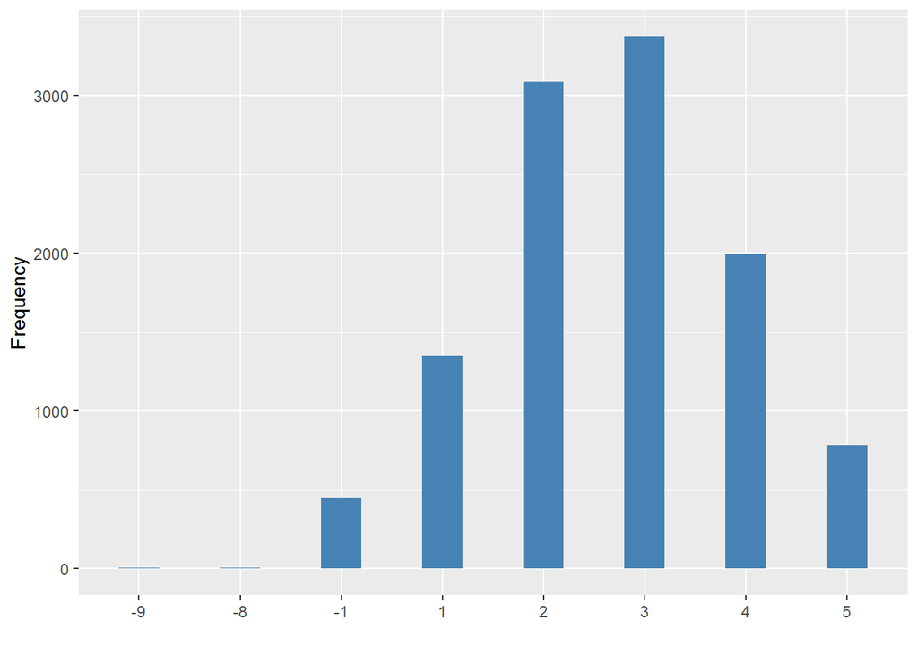

#### 2.1.4.2 Harmonisation algorithm

To compute the harmonize variable from the study-specific variable it has to be recoded as follows:

- `1 into 1`
- `2 into 1`
- `3 into 1`
- `4 into 2`
- `5 into 3`
- `-9 Refusal into 997`
- `-8 Don't know into 998`
- `-1 Not applicable into 996`

**R script:**

```r
ELSA_ds_w4 <- tibble(id = ELSA_w4_srh$id)
ELSA_ds_w4$srh <- car::recode(ELSA_w4_srh$hehelf, "1 = '1';2 = '1';3 = '1';4 = '2';5 = '3';-9 = '997';-8 = '998';-1 = '996' ")
```

#### 2.1.4.3 Statistical description of the new harmonised variable

Self Rated Health

| Sample size | Missing values |
| --- | --- |
| 11050 | 456 |

Category

|  | 1 | 2 | 3 |
| --- | --- | --- | --- |
| Frequency | 7819.00 | 1994.00 | 781.00 |
| Percentage | 70.76 | 18.05 | 7.07 |

Type of missing

|  | 991 | 992 | 993 | 994 | 995 | 996 | 997 | 998 | 999 | NA |
| --- | --- | --- | --- | --- | --- | --- | --- | --- | --- | --- |
| Frequency | 0 | 0 | 0 | 0 | 0 | 446.00 | 6.00 | 4.00 | 0 | 0 |
| Percentage | 0 | 0 | 0 | 0 | 0 | 4.04 | 0.05 | 0.04 | 0 | 0 |

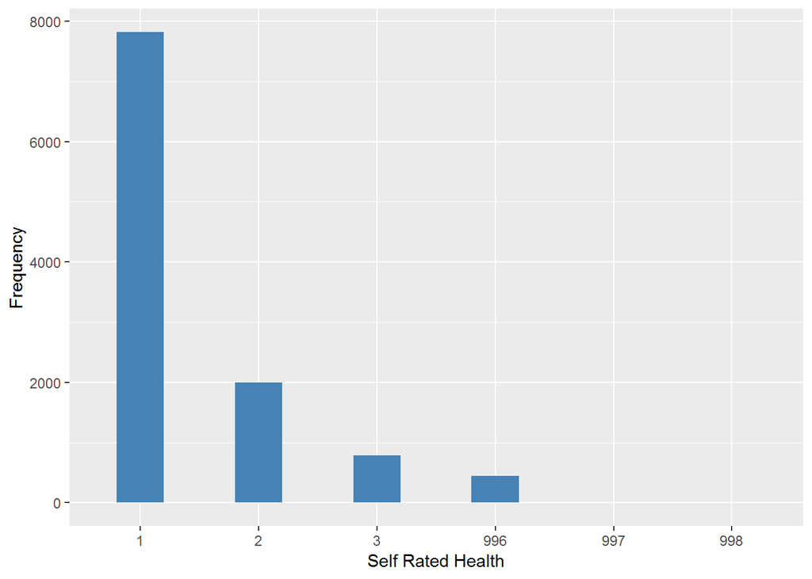

#### 2.1.4.4 Validation

|  | 1,2,3->1 | 4->2 | 5->3 | -1->996 | -9->997 | -8->998 |
| --- | --- | --- | --- | --- | --- | --- |
| BeforeH | 7819 | 1994 | 781 | 446 | 6 | 4 |
| AfterH | 7819 | 1994 | 781 | 446 | 6 | 4 |

### 2.1.5 Wave 5

#### 2.1.5.1 Study-specific variable description

| **Name** | `hehelf` |
| --- | --- |
| **Label** | `Self-reported general health` |
| **Table name** | `wave_5_elsa_data_v4` |
| **Categories** | `1 = Excellent` `2 = Very good` `3 = Good` `4 = Fair` `5 = Poor` |
| **Missings** | `-9 = Refusal` `-8 = Don't know` `-1 = Not applicable` |
| **Description** |  |

hehelf

| Sample size | Missing values |
| --- | --- |
| 10274 | 549 |

Category

|  | 1 | 2 | 3 | 4 | 5 |
| --- | --- | --- | --- | --- | --- |
| Frequency | 1180.00 | 2902.00 | 3094.00 | 1792.00 | 757.00 |
| Percentage | 11.49 | 28.25 | 30.11 | 17.44 | 7.37 |

Type of missing

|  | -9 | -8 | -1 | NA |
| --- | --- | --- | --- | --- |
| Frequency | 4.00 | 8.00 | 537.00 | 0 |
| Percentage | 0.04 | 0.08 | 5.23 | 0 |

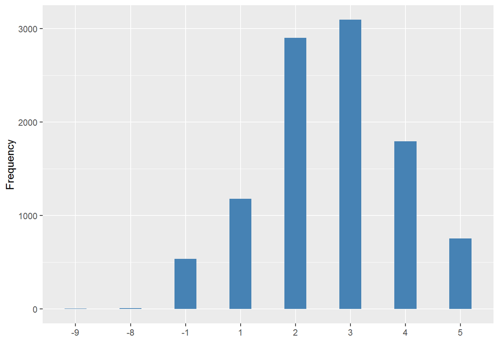

#### 2.1.5.2 Harmonisation algorithm

To compute the harmonize variable from the study-specific variable it has to be recoded as follows:

- `1 into 1`
- `2 into 1`
- `3 into 1`
- `4 into 2`
- `5 into 3`
- `-9 Refusal into 997`
- `-8 Don't know into 998`
- `-1 Not applicable into 996`

**R script:**

```r
ELSA_ds_w5 <- tibble(id = ELSA_w5_srh$id)
ELSA_ds_w5$srh <- car::recode(ELSA_w5_srh$hehelf, "1 = '1';2 = '1';3 = '1';4 = '2';5 = '3';-9 = '997';-8 = '998';-1 = '996' ")
```

#### 2.1.5.3 Statistical description of the new harmonised variable

Self Rated Health

| Sample size | Missing values |
| --- | --- |
| 10274 | 549 |

Category

|  | 1 | 2 | 3 |
| --- | --- | --- | --- |
| Frequency | 7176.00 | 1792.00 | 757.00 |
| Percentage | 69.85 | 17.44 | 7.37 |

Type of missing

|  | 991 | 992 | 993 | 994 | 995 | 996 | 997 | 998 | 999 | NA |
| --- | --- | --- | --- | --- | --- | --- | --- | --- | --- | --- |
| Frequency | 0 | 0 | 0 | 0 | 0 | 537.00 | 4.00 | 8.00 | 0 | 0 |
| Percentage | 0 | 0 | 0 | 0 | 0 | 5.23 | 0.04 | 0.08 | 0 | 0 |

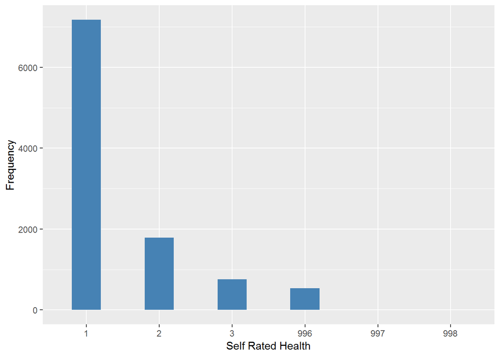

#### 2.1.5.4 Validation

|  | 1,2,3->1 | 4->2 | 5->3 | -1->996 | -9->997 | -8->998 |
| --- | --- | --- | --- | --- | --- | --- |
| BeforeH | 7176 | 1792 | 757 | 537 | 4 | 8 |
| AfterH | 7176 | 1792 | 757 | 537 | 4 | 8 |

### 2.1.6 Wave 6

#### 2.1.6.1 Study-specific variable description

| **Name** | `Hehelf` |
| --- | --- |
| **Label** | `Self-reported general health` |
| **Table name** | `wave_6_elsa_data_v2` |
| **Categories** | `1 = Excellent` `2 = Very good` `3 = Good` `4 = Fair` `5 = Poor` |
| **Missings** | `-9 = Refusal` `-8 = Don't know` `-1 = Not applicable` |
| **Description** |  |

Hehelf

| Sample size | Missing values |
| --- | --- |
| 10601 | 622 |

Category

|  | 1 | 2 | 3 | 4 | 5 |
| --- | --- | --- | --- | --- | --- |
| Frequency | 1212.00 | 2892.00 | 3156.00 | 1919.0 | 800.00 |
| Percentage | 11.43 | 27.28 | 29.77 | 18.1 | 7.55 |

Type of missing

|  | -9 | -8 | -1 | NA |
| --- | --- | --- | --- | --- |
| Frequency | 4.00 | 4.00 | 614.00 | 0 |
| Percentage | 0.04 | 0.04 | 5.79 | 0 |

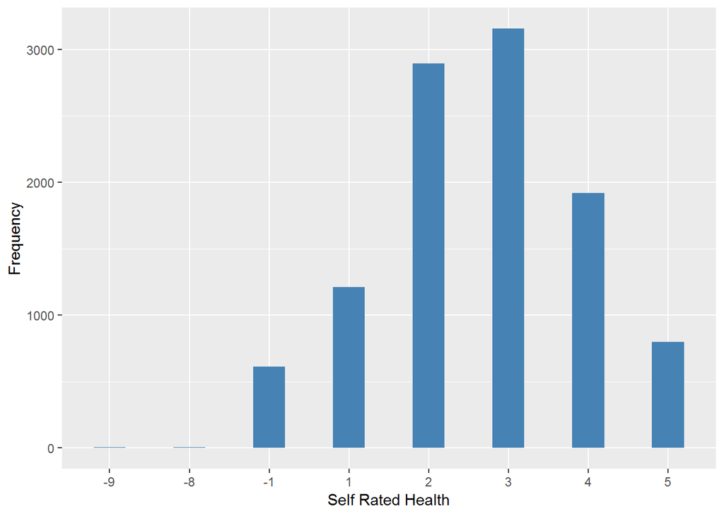

#### 2.1.6.2 Harmonisation algorithm

To compute the harmonize variable from the study-specific variable it has to be recoded as follows:

- `1 into 1`
- `2 into 1`
- `3 into 1`
- `4 into 2`
- `5 into 3`
- `-9 Refusal into 997`
- `-8 Don't know into 998`
- `-1 Not applicable into 996`

**R script:**

```r
ELSA_ds_w6 <- tibble(id = ELSA_w6_srh$id)
ELSA_ds_w6$srh <- car::recode(ELSA_w6_srh$Hehelf, "1 = '1';2 = '1';3 = '1';4 = '2';5 = '3';-9 = '997';-8 = '998';-1 = '996' ")
```

#### 2.1.6.3 Statistical description of the new harmonised variable

Self Rated Health

| Sample size | Missing values |
| --- | --- |
| 10601 | 622 |

Category

|  | 1 | 2 | 3 |
| --- | --- | --- | --- |
| Frequency | 7260.00 | 1919.0 | 800.00 |
| Percentage | 68.48 | 18.1 | 7.55 |

Type of missing

|  | 991 | 992 | 993 | 994 | 995 | 996 | 997 | 998 | 999 | NA |
| --- | --- | --- | --- | --- | --- | --- | --- | --- | --- | --- |
| Frequency | 0 | 0 | 0 | 0 | 0 | 614.00 | 4.00 | 4.00 | 0 | 0 |
| Percentage | 0 | 0 | 0 | 0 | 0 | 5.79 | 0.04 | 0.04 | 0 | 0 |

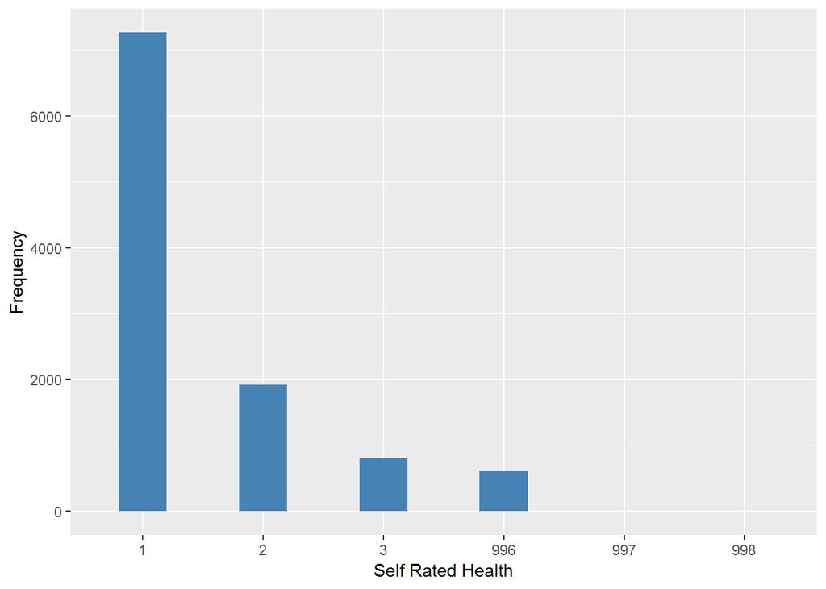

#### 2.1.6.4 Validation

|  | 1,2,3->1 | 4->2 | 5->3 | -1->996 | -9->997 | -8->998 |
| --- | --- | --- | --- | --- | --- | --- |
| BeforeH | 7260 | 1919 | 800 | 614 | 4 | 4 |
| AfterH | 7260 | 1919 | 800 | 614 | 4 | 4 |

### 2.1.7 Wave 7

#### 2.1.7.1 Study-specific variable description

| **Name** | `Hehelf` |
| --- | --- |
| **Label** | `Self-reported general health` |
| **Table name** | `wave_7_elsa_data` |
| **Categories** | `1 = Excellent` `2 = Very good` `3 = Good` `4 = Fair` `5 = Poor` |
| **Missings** | `-8 = Don't know` `-1 = Not applicable` |
| **Description** |  |

Hehelf

| Sample size | Missing values |
| --- | --- |
| 9666 | 600 |

Category

|  | 1 | 2 | 3 | 4 | 5 |
| --- | --- | --- | --- | --- | --- |
| Frequency | 1076.00 | 2640.00 | 2989.00 | 1682.0 | 679.00 |
| Percentage | 11.13 | 27.31 | 30.92 | 17.4 | 7.02 |

Type of missing

|  | -8 | -1 | NA |
| --- | --- | --- | --- |
| Frequency | 3.00 | 597.00 | 0 |
| Percentage | 0.03 | 6.18 | 0 |

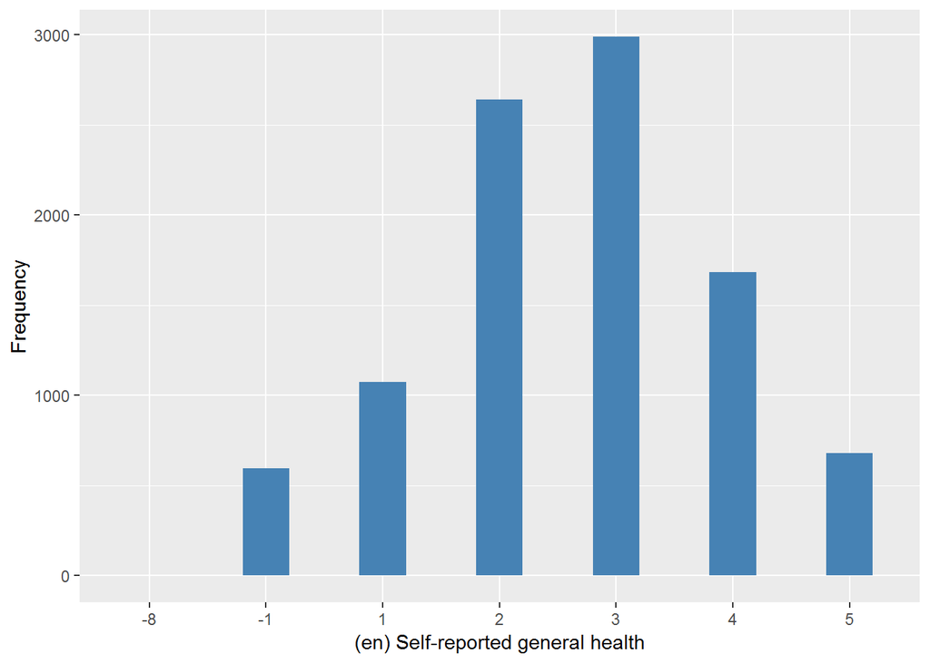

#### 2.1.7.2 Harmonisation algorithm

To compute the harmonize variable from the study-specific variable it has to be recoded as follows:

- `1 into 1`
- `2 into 1`
- `3 into 1`
- `4 into 2`
- `5 into 3`
- `-8 Don't know into 998`
- `-1 Not applicable into 996`

**R script:**

```r
ELSA_ds_w7 <- tibble(id = ELSA_w7_srh$id)
ELSA_ds_w7$srh <- car::recode(ELSA_w7_srh$Hehelf, "1 = '1';2 = '1';3 = '1';4 = '2';5 = '3';-9 = '997';-8 = '998';-1 = '996' ")
```

#### 2.1.7.3 Statistical description of the new harmonised variable

Self Rated Health

| Sample size | Missing values |
| --- | --- |
| 9666 | 600 |

Category

|  | 1 | 2 | 3 |
| --- | --- | --- | --- |
| Frequency | 6705.00 | 1682.0 | 679.00 |
| Percentage | 69.37 | 17.4 | 7.02 |

Type of missing

|  | 991 | 992 | 993 | 994 | 995 | 996 | 997 | 998 | 999 | NA |
| --- | --- | --- | --- | --- | --- | --- | --- | --- | --- | --- |
| Frequency | 0 | 0 | 0 | 0 | 0 | 597.00 | 0 | 3.00 | 0 | 0 |
| Percentage | 0 | 0 | 0 | 0 | 0 | 6.18 | 0 | 0.03 | 0 | 0 |

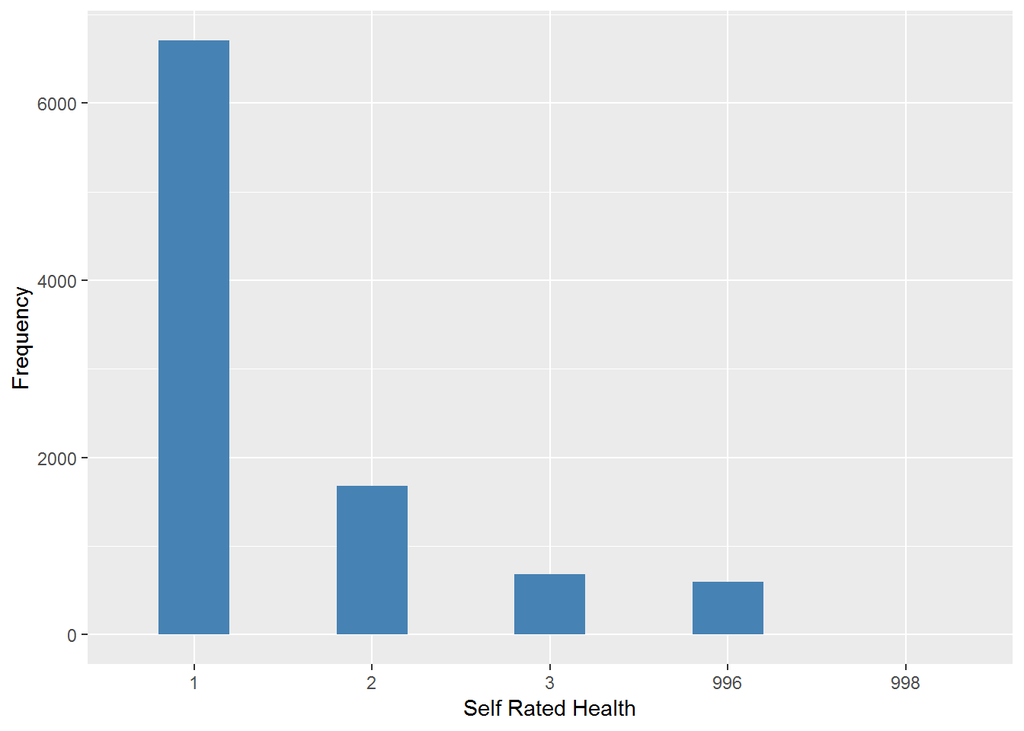

#### 2.1.7.4 Validation

|  | 1,2,3->1 | 4->2 | 5->3 | -1->996 | -8->998 |
| --- | --- | --- | --- | --- | --- |
| BeforeH | 6705 | 1682 | 679 | 597 | 3 |
| AfterH | 6705 | 1682 | 679 | 597 | 3 |

## 2.2 Summary of descriptive statistics of the harmonised variable accross populations and waves

Two tables are generated:

1. Percentages of categories in each harmonised variable.
2. Frequencies and percentages of individuals with different trajectories. To avoid too large table, Only trajectories with percentages larger than 0.3 are shown.

Self Rated Health

| val | label | W1 | W2 | W3 | W4 | W5 | W6 | W7 |
| --- | --- | --- | --- | --- | --- | --- | --- | --- |
| 1 | good | 67.8 | 71.15 | 66.9 | 70.76 | 69.85 | 68.48 | 69.37 |
| 2 | average/fair/moderate | 22.08 | 19.9 | 23.86 | 18.05 | 17.44 | 18.1 | 17.4 |
| 3 | poor | 8.54 | 7.49 | 6.82 | 7.07 | 7.37 | 7.55 | 7.02 |
| 991 | CAPI interviewer error | 0 | 0 | 0 | 0 | 0 | 0 | 0 |
| 992 | Impute | 0 | 0 | 0 | 0 | 0 | 0 | 0 |
| 993 | Disable to measure | 0 | 0 | 0 | 0 | 0 | 0 | 0 |
| 994 | Not attempt not done | 0 | 0 | 0 | 0 | 0 | 0 | 0 |
| 995 | Does not answer | 0 | 0 | 0 | 0 | 0 | 0 | 0 |
| 996 | Not applicable | 1.45 | 1.4 | 2.37 | 4.04 | 5.23 | 5.79 | 6.18 |
| 997 | Refuse | 0.04 | 0.01 | 0 | 0.05 | 0.04 | 0.04 | 0 |
| 998 | Do not know | 0.09 | 0.05 | 0.05 | 0.04 | 0.08 | 0.04 | 0.03 |
| 999 | Missing | 0 | 0 | 0 | 0 | 0 | 0 | 0 |
| NA | NA | 0 | 0 | 0 | 0 | 0 | 0 | 0 |
| n | sample size | 12099 | 9432 | 9771 | 11050 | 10274 | 10601 | 9666 |

|  | val | frq | raw.prc |
| --- | --- | --- | --- |
| 1 | 1111111 | 2054 | 11.11 |
| 2 | 1111112 | 135 | 0.73 |
| 4 | 111111NA | 222 | 1.20 |
| 5 | 1111121 | 102 | 0.55 |
| 6 | 1111122 | 62 | 0.34 |
| 16 | 11111NANA | 165 | 0.89 |
| 17 | 1111211 | 75 | 0.41 |
| 50 | 1111NANANA | 255 | 1.38 |
| 51 | 1112111 | 55 | 0.30 |
| 128 | 111NANANANA | 413 | 2.23 |
| 129 | 1121111 | 120 | 0.65 |
| 219 | 112NANANANA | 79 | 0.43 |
| 300 | 11NANANANANA | 656 | 3.55 |
| 431 | 122NANANANA | 55 | 0.30 |
| 478 | 12NANANANANA | 153 | 0.83 |
| 578 | 1NA1NANANANA | 60 | 0.32 |
| 656 | 1NANANANANANA | 1213 | 6.56 |
| 657 | 2111111 | 88 | 0.48 |
| 841 | 21NANANANANA | 110 | 0.59 |
| 993 | 222NANANANA | 77 | 0.42 |
| 1067 | 22NANANANANA | 168 | 0.91 |
| 1154 | 23NANANANANA | 72 | 0.39 |
| 1243 | 2NANANANANANA | 592 | 3.20 |
| 1493 | 33NANANANANA | 86 | 0.47 |
| 1527 | 3NANANANANANA | 328 | 1.77 |
| 1581 | NANA11111 | 474 | 2.56 |
| 1584 | NANA1111NA | 69 | 0.37 |
| 1593 | NANA111NANA | 55 | 0.30 |
| 1617 | NANA11NANANA | 91 | 0.49 |
| 1678 | NANA1NANANANA | 238 | 1.29 |
| 1763 | NANA2NANANANA | 67 | 0.36 |
| 1810 | NANANA1111 | 987 | 5.34 |
| 1811 | NANANA1112 | 68 | 0.37 |
| 1813 | NANANA111NA | 123 | 0.67 |
| 1824 | NANANA11NANA | 109 | 0.59 |
| 1859 | NANANA1NANANA | 249 | 1.35 |
| 1906 | NANANA2NANANA | 66 | 0.36 |
| 1972 | NANANANANA11 | 652 | 3.53 |
| 1973 | NANANANANA12 | 56 | 0.30 |
| 1975 | NANANANANA1NA | 197 | 1.07 |
| 1984 | NANANANANANA1 | 378 | 2.04 |
| 1985 | NANANANANANA2 | 62 | 0.34 |
| 1987 | NANANANANANANA | 468 | 2.53 |

# 3 Quality estimation

W1: the participant was randomly assigned to version 1 or version 2. PSSJD work team decided to take only the first question answered by the participant based on the conclusions extracted in Bowling and Windsor - JECH 2008;62:81?85. Other waves: No comments